# Precision, Accuracy and Speed for scientific computations

### Floating point computation

- what is "numerical precision"
- how non-integer numbers behave in a computer
- some tricks to not lose precision

### Vectorization and computational speed

- what is vectorization
- the **numpy** library

# Precision

## Floating point numbers

when we discuss numerical computation, you will see the non-integer numbers referred as **floating point numbers**.

- what are they
- how are they related with the numbers we manipulate normally?

### Some rules to keep in mind

- as soon as you start working on a computer, you have to forget about the idea of **continuous**
- any number that a computer can manipulate and output is, by necessity, with **finite precision**, and only an approximation of a **real number** (as in, a member of the real group)

numbers is a computer a represented with a finite numbers of **bits**. integers are simply the traditional integer numbers expressed in binary format, and can range from 8 bits (one byte) to 64 bits

How would you represent a number with a non integer part?

one could use a fixed part of your available bites to represent the integer part and another one to represent the floating point part, but this would severely limit the range of numbers that can be described.

the other option is to use the scientic notation to represent them: this way you can get almost as big or small as needed!

To represent the number we divide it in 3 components:

- a field called Significant **S**
- a field called exponent **e**
- a bit for the sign

so the number will represent the following:

$n = (-1)^s \cdot S \cdot 2^e$

## Precision and round off

due to the limited nature of the floating point numbers, we will have problems representing some numbers:

- irrational numbers ($\sqrt{2}$, $\pi$)
- several rational numbers

the first one might not be a surprise, but the second one is quite surprising: the information contained in them is finite!

the problem is that those numbers still requires an **infinite number of digits** to be written down.

think of the fraction $2/3 = 0.(\overline{6})$

if one has to work with a finite number of digits, it would be represented as: $2/3 = 0.66666667$

that is an approximation, and could lead to numerical imprecision, but it's the best we can do with finite space.

A common source of errors is that the "simple" fractions in base ten might not have a finite representation in base 2.

for example, 0.1, is represented as $0.0(\overline{0011})$

```python
# writing 0.1 with 32 significant digits
print("{:f} = {:.32f}".format(0.1, 0.1))
print("{:.17f} + {:.17f} = {:.17f}".format(0.1, 0.2, 0.1 + 0.2))

# python hides the horrible truth from you
print(0.1)
```

```
0.100000 = 0.10000000000000000555111512312578
0.10000000000000001 + 0.20000000000000001 = 0.30000000000000004
0.1
```

therefore:

```
0.1 + 0.1 + 0.1 - 0.3
```

returns

$5.5\ldots \cdot 10^{-17}$

instead of 0

Python works with 53 bit of precision, so the values that is working with internally are not the same as the ones that it shows using a simple print

> "If Python were to print the true decimal value of the binary approximation stored for 0.1, it would have to display **0.1000000000000000055511151231257827021181583404541015625** that is more digits than most people find useful."

> -- [Python documentation on the floating points](https://python.readthedocs.io/fr/latest/tutorial/floatingpoint.html)

## Floating point arithmetics

Due to their structure, floating point arithmetics is not equivalent to the one you are familiar with using the real numbers

- associativity(+) : $(x+y)+z \neq x + (y+z)$
- associativity($\times$) : $(x \times y) \times z \neq x \times (y \times z)$
- distributivity : $x \times (y+z) \neq (x \times y)+(x \times z)$
- round : $x + \epsilon - x \neq \epsilon$
- division : $a/b \neq a \times (1/b)$
- algorithms : $(a+b) \times (a-b) \neq a^2-b^2$
- ecc.

```python
a = 0.1
b = 0.2
c = 0.3
print((a + b) + c, a + (b + c))
#verify the associative property (+) including all bits
assert((a + b) + c == a + (b + c))
```

```
0.6000000000000001 0.6
```

```
---------------------------------------------------------------------------
AssertionError                            Traceback (most recent call last)
<ipython-input-4-1b280911bc05> in <module>
      3 c = 0.3
      4 print ((a + b) + c, a + (b + c))
----> 5 assert((a + b) + c == a + (b + c)) #verifica della proprietà associativa(+) considerando tutti i bit

AssertionError:
```

Exact fractions, on the other end, are all the fractions that can be expressed as $1/2^N$:

- 0.5
- 0.25
- 0.125
- ...

for an extensive explaination, read [What Every Computer Scientist Should Know About Floating-Point Arithmetic](https://docs.oracle.com/cd/E19957-01/806-3568/ncg_goldberg.html)

if you have to test is two floating point numbers are **close enough** to be for all intent and purposes considered equal, you can use the function `math.isclose`:

```
>>> import math
>>> a = 5.0
>>> b = 4.99998
>>> math.isclose(a, b, abs_tol=0.00003)
True
>>> math.isclose(a, b, abs_tol=0.00001)
False
>>> math.isclose(a, b, rel_tol=1e-5)
True
>>> math.isclose(a, b, rel_tol=1e-6)
False
```

If you don't care about numerical performances, you can also use the builtins modules **decimal** and **fraction**

```
>>> from decimal import getcontext, Decimal
>>> getcontext().prec = 6
>>> Decimal(1) / Decimal(7)
Decimal('0.142857')
>>> getcontext().prec = 28
>>> Decimal(1) / Decimal(7)
Decimal('0.1428571428571428571428571429')
```

```
>>> from fractions import Fraction
>>> Fraction(16, -10)
Fraction(-8, 5)
>>> Fraction('-3/7')
Fraction(-3, 7)
>>> Fraction('1.414213')
Fraction(1414213, 1000000)
>>> Fraction('7e-6')
Fraction(7, 1000000)
```

```
>>> Fraction(2.25)
Fraction(9, 4)
>>> Fraction(1.1) # why?
Fraction(2476979795053773, 2251799813685248)
>>> from decimal import Decimal
>>> Fraction(Decimal('1.1'))
Fraction(11, 10)
```

## Floating point exceptions

alongside precision errors and round offs, there are several possible exceptions that can be raised while operating with floating point numbers.

They are defined by the IEEE standard

- **Underflow** : the result of an operation is too small to be represented with a number
- **Overflow** : the result of an operation is too big to be represented with a number
- **Divide-by-zero** : when one tries to divide by 0
- **Invalid** : when the operation is not well defined (es. (0.0 / 0.0).
- **Inexact** : happens when the result of the operation is strongly approximated

# Accuracy

## The algorithm matters!

Given the properties of the floating point numbers, different ways of performing your calculations can yield wildly different results!

choosing the best algorithm is a craft, that needs to consider the floating point arithmetics, but also to balance it with the computational requirements in terms of memory and time!

## An example - the average

Lets suppose that we want to evaluate the average of a vector $x$.

we can estimate it using

$E[x] = \sum_{i=1}^N \frac{x_i}{N}$

or

$E[x] = \frac{1}{N}\sum_{i=1}^N x_i$

From a real number perspective these two versions are exactly equal, but for floating points they are not!

```python
import random
N = 1000
x = [random.normalvariate(mu=0, sigma=0.1) for i in range(N)]
mean_1 = 0.0
mean_2 = 0.0
for x_i in x:
    mean_1 += x_i / N
    mean_2 += x_i
mean_2 /= N
print("Media 1 = {:.32g}".format(mean_1))
print("Media 2 = {:.32g}".format(mean_2))
print("difference = {:.4g}".format(mean_2-mean_1))
```

```
Media 1 = -0.001613657043592960516759093891892
Media 2 = -0.0016136570435929592157164869092867
difference = 1.301e-18
```

For the estimate of the variance the results can be even more extremes:

in certain cases we can obtain a negative variance using the usual formula!

if you want to read more, check [Comparing three methods of computing standard deviation](https://www.johndcook.com/blog/2008/09/26/comparing-three-methods-of-computing-standard-deviation/)

On the other end, sometimes a less precise algorithm can be preferred simply due to its **speed**.

On a traditional CPU different operations have wildly different execution times, and this could lead to dramatic differences in approach!

## Cost of Operations

[figure not shown]

A consequence of this is that performing different operations that should be the same can have massive performance gain. (an example with a spoiler)

```python
import numpy as np
a = np.random.randn(100_000)
```

```python
%timeit a/2
```

```
59.4 µs ± 1.42 µs per loop (mean ± std. dev. of 7 runs, 10,000 loops each)
```

```python
%timeit a*0.5
```

```
35.6 µs ± 632 ns per loop (mean ± std. dev. of 7 runs, 10,000 loops each)
```

this can create some mind bending effect performance wise

```python
%timeit a*1/2
```

```
101 µs ± 1.74 µs per loop (mean ± std. dev. of 7 runs, 10,000 loops each)
```

```python
%timeit 1/2*a
```

```
37.1 µs ± 336 ns per loop (mean ± std. dev. of 7 runs, 10,000 loops each)
```

A classic example from computer science is the inverse of a square root of a number

$$ \frac{1}{\sqrt{x}} $$

you could use the standard formula, and obtain a reasonably good result:

```python
from math import sqrt
print(1/sqrt(4))
```

```
0.5
```

## But

somebody (it is actually not known who) developed the following monster to do the same operation

```python
def isqrt(number):
    import numpy as np
    assert number > 0
    threehalfs = 1.5
    x2 = number * 0.5
    y = np.float32(number) # converting the number to float32

    i = y.view(np.int32) #convert y to a int32 variable
    magic = np.int32(0x5f3759df) # magic number,  nobody knows why it works
    i = magic - np.int32(i >> 1) #difference bit-wise of the numbers
    y = i.view(np.float32)

    y = y * (threehalfs - (x2 * y * y))
    return float(y)

print(isqrt(4))
```

```
0.49915357479239103
```

This algorithm is less precise and more complicated, but it's so much faster than the naive implementation that is single handedly considered the code that allowed the birth of modern first person shooting games!

this is because this expression appears countless times in the dynamic light computation (to decrease it with distance), and this was fast and precise enough to allow to be used in real time

**note**: this algorithm is actually performing the first step of a newton minimization algorithm

## Cost of Functions

[figure not shown]

# Speed

there are several ways to speed up and optimize an algorithm, and each one of them is appropriate to different situations:

- memory access optimization
- code parallelization
- **code vectorization**

The last one is the idea of expressing operations on entire data structures, and letting the CPU perform them on all the element at once.

the performance increase comes from a reduction of the cache I/O between CPU and RAM, a huge bottleneck in operations. (we will see the `numexpr` library for even more optimization)

### Single Instruction Multiple Data

[figure not shown]

So we can use vectorization when:

- we have a loop over a data structure
- each step of the loop can be executed in parallel over the elements of the structure

vectorization is one of the easiest methods to implement and that have the best gain for effort... especially in high level programming languages

# NumPy - Numerical Python

**Numpy** is the library that underpins all the python scientific ecosystem, for high performance computation and data analysis

The library provides an object, the **array** (*ndarray*, to be specific), that support vectorized and parallel computation, allowing high performance math in python, to a speed that can rival C (if properly implemented)

The library also provides most common manipulation algorithms (later we'll discuss the extensions with **scipy**), all implemented in a vectorized fashion, but also read and write capabilities, tabular data manipulation, linear algebra, and even C++ code wrapping!

Good reference book (free online) are:

- [From Python to Numpy](https://www.labri.fr/perso/nrougier/from-python-to-numpy/)
- [Scipy Lecture Notes](https://scipy-lectures.org/)

```python
import numpy as np
# vector 1x4
a = np.array([1,2,3,4])
print("a = ", a)
# bidimensional array (matrix) 2x4
b = np.array([
    [1,2,3,4],
    [5,6,7,8],
])
print("b = \n", b)
```

```
a =  [1 2 3 4]
b =
 [[1 2 3 4]
 [5 6 7 8]]
```

Every array has the following functions and methods available:

- array.shape : returns the dimensions of the array (a tuple of lenght alongside each dimension)
- array.dtype : returns the type of data inside the array (array are homogeneous)
- len(array) : return the size of the **rows** (the first dimension) of a multidimensional array (the dimensione over which you can loop over)
- np.array(list) o np.array(tuple) : convert them in a numpy array

```python
a = [1,2,3,4]
a_array = np.array(a)
b_array = np.asarray(list(a))
print(a_array.shape)
print(b_array.shape)
print(a_array.dtype)
print(len(a_array))
```

```
(4,)
(4,)
int64
4
```

it is also possible to specify the type of numbers that the array should contains. **NOTE**: in a numpy array all the values have the same type!

https://docs.scipy.org/doc/numpy/user/basics.types.html

different data types can massively change the array size, and this could be a life saver when memory is limited!

(sadly there is no simple way of managing 1-bit arrays for booleans)

```python
a = [1,2,3,4]
print(np.array(a, dtype='uint8'))
print(np.array(a, dtype='float32'))
print(np.array(a, dtype='complex'))
```

```
[1 2 3 4]
[1. 2. 3. 4.]
[1.+0.j 2.+0.j 3.+0.j 4.+0.j]
```

```python
a = np.array([1, 2, 3, 4], dtype='uint8')
print(a.size, a.itemsize, a.nbytes)
```

```
4 1 4
```

```python
a = np.array([1, 2, 3, 4], dtype='float64')
print(a.size, a.itemsize, a.nbytes)
```

```
4 8 32
```

```python
a = np.array([1, 2, 3, 4], dtype='complex')
print(a.size, a.itemsize, a.nbytes)
```

```
4 16 64
```

```python
a = np.array([1,2,3,4], dtype=np.float64)
print ("a = ", a)
print ("a contains elements of type : ", a.dtype)
```

```
a =  [1. 2. 3. 4.]
a contains elements of type :  float64
```

```python
a = np.array([1,2,3,4], dtype=np.uint32)
print ("a = ", a)
print ("a contains elements of type : ", a.dtype)
```

```
a =  [1 2 3 4]
a contains elements of type :  uint32
```

```python
a = np.array(['1.21', '.2', '-.4'], dtype = np.string_)
print ("a is made out of strings = ", a)
print ("a cast to float = ", a.astype(np.float64))
```

```
a is made out of strings =  [b'1.21' b'.2' b'-.4']
a cast to float =  [ 1.21  0.2  -0.4 ]
```

## Create an array

There are 3 important functions to create an array

```python
array_zeros = np.zeros(10) # vector of 1x10 zeros
print ("array_zeros = ", array_zeros)
```

```
array_zeros =  [0. 0. 0. 0. 0. 0. 0. 0. 0. 0.]
```

```python
a_matzeros = np.zeros((2,10)) # 2d array of 2x10 zeros
print ("a_matzeros has dimensions : ", a_matzeros.shape)
```

```
a_matzeros has dimensions :  (2, 10)
```

```python
array_ones = np.ones(10) # vector of 1x10 one
print ("array_ones = ", array_ones)
```

```
array_ones =  [1. 1. 1. 1. 1. 1. 1. 1. 1. 1.]
```

```python
a_empty = np.empty(20) # vector 1x20 of null values (from the free memory used)
print ("a_empty = ", a_empty)
print ("a_empty contains objects of type : ", a_empty.dtype)
```

```
a_empty =  [ 4.64555917e-310  0.00000000e+000  6.90511319e-310  1.36659607e-226
  6.90511319e-310  6.90511319e-310 -2.31706182e+033  6.90511319e-310
  6.90511319e-310 -1.79276248e-244  6.90511399e-310  6.90511319e-310
  3.85332059e-049  6.90511319e-310  6.90511319e-310 -3.24679520e-211
  6.90511319e-310  6.90511319e-310 -1.62550434e-194  6.90511400e-310]
a_empty contains objects of type :  float64
```

## Beware

**np.empty** does not contains zeros, but basically random numbers.

They are not properly random, but "garbage" remaining from the values of the previous of that section of memory

often one might need to create a simple array (such as ones or zeros) in the same shape as another. a first solution might be to use the shape of the first array:

```python
a = np.array([1,2,3,4])
b = np.ones(a.shape)
print(b)
```

```
[1. 1. 1. 1.]
```

but this looks a bit cluncky and the data type is mismatched to the original one (the original was of integers, the generated one is of float).

So a convenient set of functions are the `ones_like`, `zeros_like`, `empty_like`, that takes the reference array as input and generates a new one with the right shape and data type

```python
a = np.array([1,2,3,4j])
b = np.ones_like(a)
print(b)
```

```
[1.+0.j 1.+0.j 1.+0.j 1.+0.j]
```

## Altri tipi di inizializzazione

## Other types of initialization

We can create array containing numbers in a specific range

The main functions are 4: `np.arange`, `np.linspace`, `np.logspace`, `np.geomspace`

```python
a = np.arange(10)
print(a)
```

```
[0 1 2 3 4 5 6 7 8 9]
```

```python
# (initial value, final value, step size)
a = np.arange(1, 10, 2)
print(a)
```

```
[1 3 5 7 9]
```

```python
# (initial value, final value, number of steps)
a = np.linspace(0, 10, 5)
print(a)
```

```
[ 0.   2.5  5.   7.5 10. ]
```

```python
# (initial value (in log), final value (in log), number of steps)
a = np.logspace(0, 2, 5, base=12)
print(a)
```

```
[  1.           3.46410162  12.          41.56921938 144.        ]
```

```python
# (initial value, final value, number of steps)
a = np.geomspace(1, 100, 5)
print(a)
```

```
[  1.           3.16227766  10.          31.6227766  100.        ]
```

## Operations between arrays and scalars

Numpy's array are not only simplifying the generation and management of data, but they have a huge number of operations that are already vectorized, such as **array-array** operations and **array-scalar**

```python
a = np.array([1,2,3,4])
b = np.array([2,3,4,5])
print ("\n ARITHMETIC OPERATIONS\n")
print ("a = ", a)
print ("b = ", b)
print ("a * 10 : ", a * 10)
print ("a + 2 : ", a + 2)
print ("a^2 : ", a**2)
```

```
 ARITHMETIC OPERATIONS

a =  [1 2 3 4]
b =  [2 3 4 5]
a * 10 :  [10 20 30 40]
a + 2 :  [3 4 5 6]
a^2 :  [ 1  4  9 16]
```

```python
print ("\n OPERATIONS BETWEEN ARRAYS\n")
print ("a * b : ", a*b)
print ("a ** b : ", a**b)
print ("a + b : ", a+b)
print ("a - b : ", a-b)
print ("1 / a : ", 1/a) # gives floats!
print ("1 / a : ", 1//a)
```

```
 OPERATIONS BETWEEN ARRAYS

a * b :  [ 2  6 12 20]
a ** b :  [   1    8   81 1024]
a + b :  [3 5 7 9]
a - b :  [-1 -1 -1 -1]
1 / a :  [1.         0.5        0.33333333 0.25      ]
1 / a :  [1 0 0 0]
```

From python 3.5 a new operator has been added for vector and matrix dot product, using the `@`.

```python
np.dot(a, b)
```

```
40
```

```python
a@b
```

```
40
```

```python
a.reshape(4,1)@b.reshape(1, 4)
```

```
array([[ 2,  3,  4,  5],
       [ 4,  6,  8, 10],
       [ 6,  9, 12, 15],
       [ 8, 12, 16, 20]])
```

```python
# they support traditional slicing syntax
a = np.arange(20)
print(a)
```

```
[ 0  1  2  3  4  5  6  7  8  9 10 11 12 13 14 15 16 17 18 19]
```

```python
print(a[8])
```

```
8
```

```python
print(a[:8])
```

```
[0 1 2 3 4 5 6 7]
```

```python
print(a[:8:2])
```

```
[0 2 4 6]
```

```python
print(a[8:12])
```

```
[ 8  9 10 11]
```

```python
print(a[12:-4])
```

```
[12 13 14 15]
```

```python
print(a[-4:])
```

```
[16 17 18 19]
```

```python
assert( np.all(a[-15:-10] == a[5:10]))
```

```python
a = np.ones((4, 4))
a[0, :2]
```

```
array([1., 1.])
```

## BEWARE!

when you slice an array, you don't get a copy unless you specifically ask for it with the `array.copy()` method. so if you modify an element, the original array will be modified as well!

```python
a = np.arange(10)
print(a)
arr_slice = a[2:5] # view of a
arr_slice[1] = 10000 # change the second element of the slice
print(a) # the original array is changed!
```

```
[0 1 2 3 4 5 6 7 8 9]
[    0     1     2 10000     4     5     6     7     8     9]
```

```python
# the Sieve of Eratosthenes, numpy version
N = 80
a = np.arange(N)
for i in range(2, N):
    a[i*2::i] = 0

print(a[np.nonzero(a)])
```

```
[ 1  2  3  5  7 11 13 17 19 23 29 31 37 41 43 47 53 59 61 67 71 73 79]
```

```python
arr3d = np.array([[[1, 2, 3], [4, 5, 6]], [[7, 8, 9], [10, 11, 12]]])
print (" a = ", arr3d)
print ("first element : ", arr3d[0, 0, 0])
print ("first element : ", arr3d[0][0][0])
print ("first row : ", arr3d[0][0])
print ("first 'matrix' : ", arr3d[0])
print ("depth : ", arr3d[:, 0, 0])
```

[output not shown]

## Going back to the example of the averages

let's see how much faster the numpy array can get

Numpy provides an already optimized version of the mean (as with a lot of other functions)

```
np.mean(array)
```

```python
import time
start_time = time.time() # inizia a contare il tempo
N = int(1e7)
x = np.random.rand(N)
mean_for_1 = 0.0
mean_for_2 = 0.0
for x_i in x:
    mean_for_1 += x_i/N
    mean_for_2 += x_i
mean_for_2 /= N
print ("Mean 1 = {:.32f}".format(mean_for_1))
print ("Mean 2 = {:.32f}".format(mean_for_2))
print ("Calculated in {:.2g} sec".format(time.time()-start_time))

start_time = time.time()
mean_vec = np.mean(x)
print ("Mean from numpy = {:.32f}".format(mean_vec))
print ("Calculated in {:.2g} sec".format(time.time()-start_time))
```

```
Mean 1 = 0.49999972637047690460221360808646
Mean 2 = 0.49999972637049688861665686090419
Calculated in 7.8 sec
Mean from numpy = 0.49999972637048045731589240858739
Calculated in 0.0054 sec
```

## Random number generation

A useful practice for scientific simulations is the generation of random number.

Numpy provides us with a wide range of random generators

```python
from numpy import random
print(random.rand()) # uniform distribution
print(random.randn()) # normal distribution
print(random.exponential()) # exponential distribution
print(random.rand(2, 3)) # random matrix
```

```
0.04188856284324605
-0.5012089524187691
0.8019130683269593
[[0.57421473 0.43093877 0.9662763 ]
 [0.44139401 0.07189704 0.87782763]]
```

to improve replicability of random simulations (we will discuss more about that) is possible to fix the **random seed**.

this will ensure that the random number generated are repeated exactly equal... this is fundamental for debugging, as it allows to replicate border cases that break your code!

```python
np.random.seed(0)
print(np.random.rand())
print(np.random.rand())
print('-'*20)
np.random.seed(0)
print(np.random.rand())
print(np.random.rand())
```

```
0.5488135039273248
0.7151893663724195
--------------------
0.5488135039273248
0.7151893663724195
```

## some other useful functions ...

```python
a = np.array([1, -2, 3.444, -2, 4.29, 6.98])
b = np.array([2, -2, 3.44, -2., 5, 7])

print("\n Some other operations \n")

print(np.abs(a)) # absolute value
print(np.fabs(a)) # absolute value
print(np.sqrt(a)) # square root
print(np.floor(a)) # the largest integer value less than or equal to x
print(np.ceil(a)) # smallest integer value greater than or equal to x
```

```
 Some other operations

[1.    2.    3.444 2.    4.29  6.98 ]
[1.    2.    3.444 2.    4.29  6.98 ]
[1.                nan 1.85580171        nan 2.07123152 2.64196896]
[ 1. -2.  3. -2.  4.  6.]
[ 1. -2.  4. -2.  5.  7.]
```

```python
a = np.array([False, False, True, False, False, False])
b = np.array([False, True, False, True, False, False])

print("\n SOME logical operations (implicit) \n")

print(a&b)
print(a|b)
print(a>b)
print(a==b)

print("\n SOME logical operations (explicit)\n")


print(np.logical_and(a, b))
print(np.logical_or(a, b))
print(np.greater(a, b))
print(np.equal(a, b))
```

```
 SOME logical operations (implicit)

[False False False False False False]
[False  True  True  True False False]
[False False  True False False False]
[ True False False False  True  True]

 SOME logical operations (explicit)

[False False False False False False]
[False  True  True  True False False]
[False False  True False False False]
[ True False False False  True  True]
```

```python
a = np.array([1, -2, 3.444, -2, 4.29, 6.98])
b = np.array([2, -2, 3.44, -2., 5, 7])

print ("\n SOME ordering operations \n")
print(np.sort(a)) # SORTING ELEMENTS
print(np.argsort(a)) # SORTING INDICES
print(np.where(a < 2)[0]) # INDICES WHERE CONDITION
print(np.where(a > 2, 1, 0)) # (CONDITION, IF(CONDITION), ELSE)
print(np.median(a)) # MEDIAN
print(a[a>0]) # CONDITIONAL SELECTION
```

```
 SOME ordering operations

[-2.    -2.     1.     3.444  4.29   6.98 ]
[1 3 0 2 4 5]
[0 1 3]
[0 0 1 0 1 1]
2.222
[1.    3.444 4.29  6.98 ]
```

## Broadcasting

Numpy can combine arrays of different sizes in a smart way, as long as they have a similar number of dimensions (or this can be padded out with sizes 1)

```python
a = np.arange(4)
print(a.shape)
a = a.reshape(4, 1)
print(a.shape)
```

```
(4,)
(4, 1)
```

```python
# I can normally sum these two arrays
a = np.arange(4)
b = np.arange(4)

a+b
```

```
array([0, 2, 4, 6])
```

```python
# If I reshape them with compatible shapes, I can still add them,
# but it broadcast over the two dimensions
a1 = a.reshape(4, 1)
b1 = b.reshape(1, 4)

a1+b1
```

[output not shown]

```python
# if the shapes are not compatible then it raises error
a1 = a.reshape(2, 2)
b1 = b.reshape(1, 4)

a1+b1
```

```
---------------------------------------------------------------------------
ValueError                                Traceback (most recent call last)
<ipython-input-85-9f255dee9d27> in <module>
      3 b1 = b.reshape(1, 4)
      4
----> 5 a1+b1

ValueError: operands could not be broadcast together with shapes (2,2) (1,4)
```

## Directional application of functions

**numpy** supports also the application of function along certain axis and not only on the whole array.

for example you can ask the sum of the rows of a matrix instead of the whole sum

```python
data = np.random.randn(4, 2)
print("mean of the whole array: \t", np.mean(data))
print("mean of the first axis: \t", np.mean(data, axis=0))
print("mean of the second axis: \t", np.mean(data, axis=1))
print("mean of the last axis:  \t", np.mean(data, axis=-1))
print("first and second axis:  \t", np.mean(data, axis=(0, 1)))
```

```
mean of the whole array: 	 0.05099235126842125
mean of the first axis: 	 [ 0.33501371 -0.23302901]
mean of the second axis: 	 [ 0.6966595  -0.4396954  -0.21533     0.16233531]
mean of the last axis:  	 [ 0.6966595  -0.4396954  -0.21533     0.16233531]
first and second axis:  	 0.05099235126842125
```

```python
matrix = np.abs(np.random.randn(3, 4))
print("original matrix:")
print(matrix)
print('-'*30)
print("sum over the columns:")
print(matrix.sum(axis=0))
print('-'*30)
print("normalized matrix (by column):")
matrix = matrix / matrix.sum(axis=0)
print(matrix)
```

```
original matrix:
[[1.91693056 0.77574042 0.62195499 0.43104792]
 [0.13647849 1.93118056 0.4266351  0.22084327]
 [0.00505452 0.83373703 1.96152037 1.91617401]]
------------------------------
sum over the columns:
[2.05846356 3.540658   3.01011046 2.5680652 ]
------------------------------
normalized matrix (by column):
[[0.93124338 0.21909499 0.20662198 0.16784929]
 [0.06630114 0.54542985 0.14173403 0.08599597]
 [0.00245548 0.23547517 0.65164398 0.74615474]]
```

Normally these operation reduce the number of dimensions of the array.

One can also apply one of these reduction operations while keeping the same number of dimensions as the previous array, using the `keepdims` option

```python
a = np.random.rand(4, 4)
print(a.sum(axis=0).shape)
print(a.sum(axis=0, keepdims=True).shape)
```

```
(4,)
(1, 4)
```

## Memory recycling

one option to optimize performance of memory use is to use an array memory space to store the result of an operation, without requiring the creation of partial results.

```python
a = np.arange(4)
b = np.arange(4)
c = np.empty(4)

np.add(a, b, out=c)
print(c)
```

```
[0. 2. 4. 6.]
```

## Numpy for scientific data

numpy array are well adapted to store and manipulate scientific data, in particular **structurally omogeneous ones**

for example, an image is described by a 3 dimensional array: lenght, width and the 3 colors.

a fluorescence microscope might return a 6 dimensional array with dimensions for:

- x, y and z
- colors (light field, various fluorescences)
- time
- well of the petri

(even if, for this kind os structures, it might be useful to use more specialized libraries such as **xarray**)

```python
from PIL import Image
from IPython.display import display
filename = "./fractal_wrongness.png"

with Image.open(filename) as im:
    print(im.size, im.mode)
    pix = np.array(im)
pix.shape
```

```
(595, 496) RGB
```

```
(496, 595, 3)
```

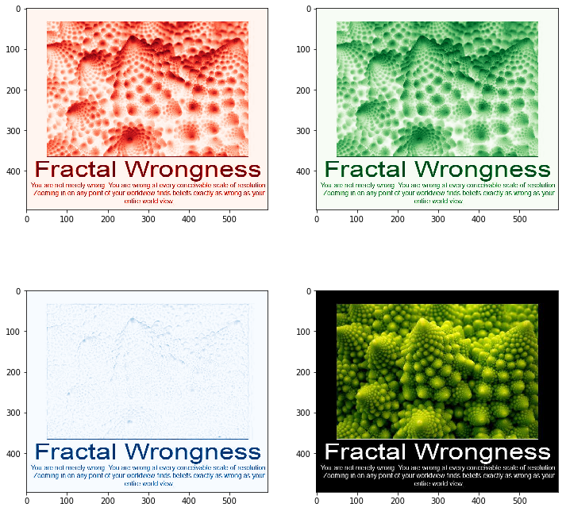

```python
import pylab as plt
fig, ((ax1, ax2), (ax3, ax4)) = plt.subplots(2, 2, figsize=(12, 12))
ax1.imshow(pix[:,:,0], cmap=plt.cm.Reds)
ax2.imshow(pix[:,:,1], cmap=plt.cm.Greens)
ax3.imshow(pix[:,:,2], cmap=plt.cm.Blues)
ax4.imshow(pix)
```

## Structured array

Numpy provides functionalities for managing tabular records of data, with the [**structured array**](https://docs.scipy.org/doc/numpy/user/basics.rec.html) data (and the more specialized **record array**).

It allows to store arbitrary tuples are items inside an array (including sub-structures or arrays)

This could be useful in some cases, but in general it would be better to use the library **pandas**, that we will discuss in the following lessons

```python
data = [
    ('Rex', 9, 81.0),
    ('Fido', 3, 27.0),
]
mydtype = [
    ('name', 'U10'), # a string
    ('age', 'i4'), # an integer
    ('weight', 'f4'), # a float
]
x = np.array(data, dtype=mydtype)
print(x)
print(x['name'])
print(x['name'][0], x[0]['name'])
```

```
[('Rex', 9, 81.) ('Fido', 3, 27.)]
['Rex' 'Fido']
Rex Rex
```